# Proyecto VaR Métodos 2020-02

Carlos David Nieto Loya (416073542)

30 de abril de 2020

### Funciones y Fuentes de datos

Primero vamos a leer los precios de la base de datos y además hacemos una función para calcular los rendimientos de nuestros precios.

```r
# Cargamos nuestros datos
df <- read.csv("prices.csv")

# Funcion que devuelve los rendimientos de los precios de un activo
get_rendimientos <- function(precios){
  # Inicializamos vector de rendimientos
  r <- c()

  # Lo llenamos mediante un for loop
  for(i in 1:(length(precios)-1)){
    r[i] <- (precios[i+1]/precios[i]) - 1
  }

  # Regresamos el vector de rendimientos
  return(r)
}
```

### Rendimientos

Calculamos los rendimientos y los almacenamos en una matriz y graficamos el histograma de estos rendimientos donde podemos ver que no es erróneo suponer normalidad.

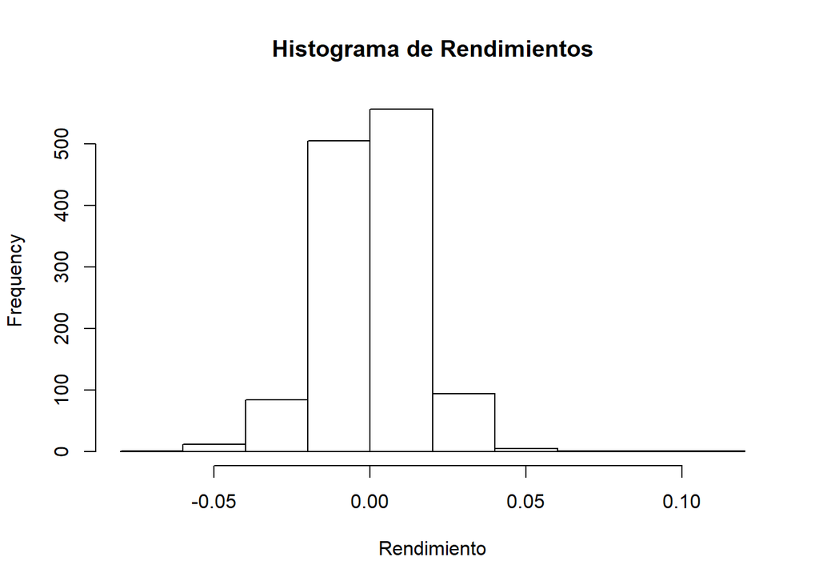

```r
n <- 5 # numero de activos

# R = Matriz de Rendimientos
# aqui vamos a almacenar los rendimientos
R <- matrix(nrow = dim(df)[1]-1, ncol = n)
for(i in 1:n){
  R[,i] <- get_rendimientos(df[,i])
}
hist(R, main = "Histograma de Rendimientos", xlab = "Rendimiento")
```

### Esperanza de los Rendimientos ($E_t$)

Calculamos esta esperanza de cada uno de los rendimientos sacando el promedio de éstos, así obtenemos $E_t$

```r
# mius = vector de Esperanzas de los rendimientos
mius <- c()

for(i in 1:dim(R)[2]){
  # promedio de cada activo
  mius[i] <- mean(R[,i])
}

print("Vector de Esperanzas")
```

```
## [1] "Vector de Esperanzas"
```

```r
print(mius)
```

```
## [1]  1.807858e-03  5.802960e-04  9.496269e-05 -5.407795e-06  9.322036e-04
```

## Portafolio de Mínima Varianza

Calculamos la matriz de varianzas y covarianzas de los rendimientos junto con su inversa y un vector de unos para poder calcular lo siguiente:

- $w$: Vector de ponderaciones del portafolio de mínima varianza.
- $\mu$: Esperanza del portafolio de mínima varianza.
- $Var(P)$: Varianza del portafolio de mínima varianza.

```r
# M = Matriz de Varianzas y Covarianzas
M <- var(R)

# M.inv = Matriz de Varianzas y Covarianzas Inversa
M.inv <- solve(M)

# Vector de unos
unos <- rep(1,5)

# w =  Vector de ponderaciones del portafolio de min var
denom <- ((t(unos)%*% M.inv) %*% unos)
w <- (t(unos)%*% M.inv)/denom[1,1]
# verificamos que la suma sea 1
print(sum(w))
```

```
## [1] 1
```

```r
# miu = Esperanza del portafolio de minima varianza
miu <- sum(w*mius)

# var.p = Varianza del Portafolio de minima varianza
var.p <- w%*%M%*%t(w)
```

### VaR (Paramétrico - normal multivariada)

Con lo calculado anteriormente podemos calcular el **VaR**. También suponemos que el monto de nuestra inversión es de 1,000,000 de pesos para poder aproximar la pérdida máxim probable.

- **VaR con $\alpha = 0.01$**

```r
# suponemos monto = 1,000,000
m <- 1000000

# VaR con alpha = 0.01
alpha1 <- 0.01
VaR1 <- qnorm(1-alpha1) * sqrt(var.p) + miu #Calculo de VaR
perdida1 <- format(m*VaR1, nsmall=2, big.mark = ",") #Calculo de perdida max
porcentaje1 <- paste(toString(100*(1-alpha1)),'%')
sprintf("VaR al %s de confianza: %.6f",porcentaje1,VaR1)
```

```
## [1] "VaR al 99 % de confianza: 0.022122"
```

```r
sprintf("Perdida Maxima: %s", perdida1)
```

```
## [1] "Perdida Maxima: 22,122.12"
```

- **VaR con $\alpha = 0.05$**

```r
# VaR con alpha = 0.05
alpha2 <- 0.05
VaR2 <- qnorm(1-alpha2) * sqrt(var.p) + miu #Calculo de VaR
perdida2 <- format(m*VaR2, nsmall=2, big.mark = ",") #Calculo de perdida max
porcentaje2 <- paste(toString(100*(1-alpha2)),'%')
sprintf("VaR al %s de confianza: %.6f",porcentaje2,VaR2)
```

```
## [1] "VaR al 95 % de confianza: 0.015805"
```

```r
sprintf("Perdida Maxima: %s", perdida2)
```

```
## [1] "Perdida Maxima: 15,804.78"
```

- **VaR con $\alpha = 0.1$**

```r
# VaR con alpha = 0.1
alpha3 <- 0.1
VaR3 <- qnorm(1-alpha3) * sqrt(var.p) + miu #Calculo de VaR
perdida3 <- format(m*VaR3, nsmall=2, big.mark = ",") #Calculo de perdida max
porcentaje3 <- paste(toString(100*(1-alpha3)),'%')
sprintf("VaR al %s de confianza: %.6f",porcentaje3,VaR3)
```

```
## [1] "VaR al 90 % de confianza: 0.012437"
```

```r
sprintf("Perdida Maxima: %s", perdida3)
```

```
## [1] "Perdida Maxima: 12,437.03"
```

## Conclusiones

```r
# DataFrame de resultados
Alpha <- c(alpha1,alpha2,alpha3)
VaR <- c(VaR1,VaR2,VaR3)
Perdida_Max <- c(perdida1, perdida2, perdida3)
df.resultados <- data.frame(Alpha, VaR, Perdida_Max)
print(df.resultados)
```

```
##   Alpha        VaR Perdida_Max
## 1  0.01 0.02212212   22,122.12
## 2  0.05 0.01580478   15,804.78
## 3  0.10 0.01243703   12,437.03
```

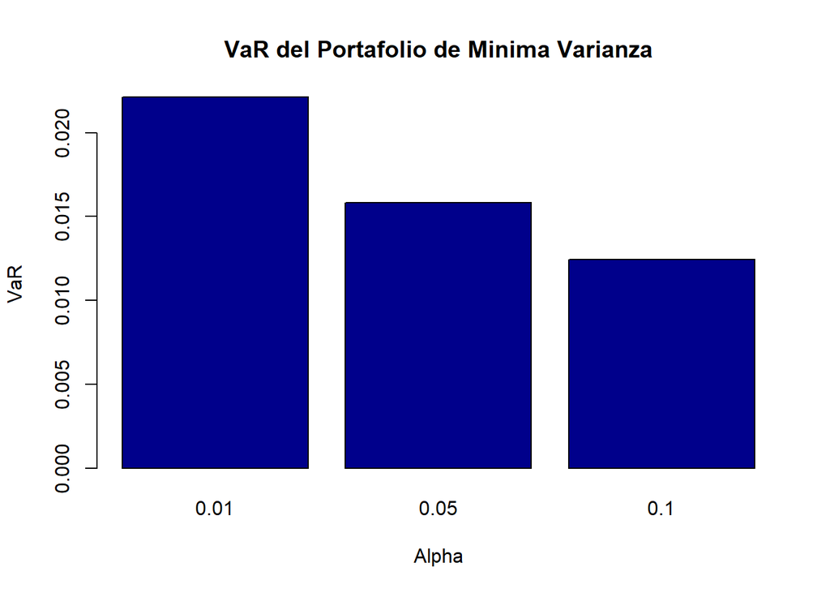

```r
# Grafica
barplot(df.resultados$VaR,
        main = "VaR del Portafolio de Minima Varianza",
        names.arg = Alpha,
        col = "darkblue",
        xlab = "Alpha",
        ylab = "VaR",
        horiz=FALSE)
```

Podemos ver que el VaR va aumentando conforme el nivel de significancia $\alpha$ disminuye, eso quiere decir que para tener un porcentaje mayor de confianza la pérdida máxima probable también aumenta.

## VaR de los Portafolios de Cada acción

Análogamente al portafolio de mínima varianza, calculamos el VaR para cada activo.

```r
# vector de VaR's
VaR.acciones <- c()

# para cada activo
for(i in 1:5){

  # Esperanza
  e <- mius[i]

  # Varianza
  v <- M[i,i]

  VaR.acciones[i] <- qnorm(1-alpha2) * sqrt(v) + e
}

# Nombres de acciones
Acciones <- c("A","B","C","D","E")
Acciones[6] <- "MinVar"

# Perdida Maxima Probable
Perdidas.acciones <- VaR.acciones * m
Perdidas.acciones[6] <- m*VaR2

# Agregamos el VaR del port de minima varianza
VaR.acciones[6] <- VaR2

# DataFrame de los VaR para cada accion
VaRs.df <- data.frame(Acciones, VaR.acciones, Perdidas.acciones)
print(VaRs.df)
```

```
##   Acciones VaR.acciones Perdidas.acciones
## 1        A   0.03352765          33527.65
## 2        B   0.02286454          22864.54
## 3        C   0.02336812          23368.12
## 4        D   0.02216732          22167.32
## 5        E   0.02388350          23883.50
## 6   MinVar   0.01580478          15804.78
```

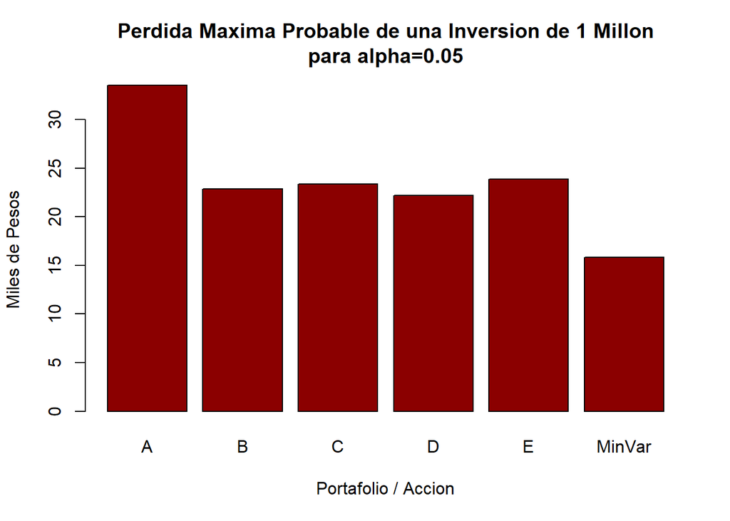

```r
barplot(VaRs.df$Perdidas.acciones/1000,
        main = "Perdida Maxima Probable de una Inversion de 1 Millon\npara alpha=0.05",
        names.arg = Acciones,
        col = "darkred",
        xlab = "Portafolio / Accion",
        ylab = "Miles de Pesos",
        horiz=FALSE)
```

Como era de esperarse podemos ver que el VaR es menor para el portafolio de mínima varianza comparandolo contra los activos individuales. Esto se refleja en que la pérdida máxima probable es menor en el portafolio de mínima varianza que en los otros.

FIN